# 7 Exploratory Data Analysis

4. Um problema com boxplot é que eles foram desenvolvidos em uma epoca que existiam muito menos dados, com a quantidade de dados de hoje, muitos dos boxplots conteram um numero de outliers muito grande. Para substituir isso existe o value plot. Instale o pacote lvplot e tente usar geom_lv(). Como voce interpreta esse gráfico.

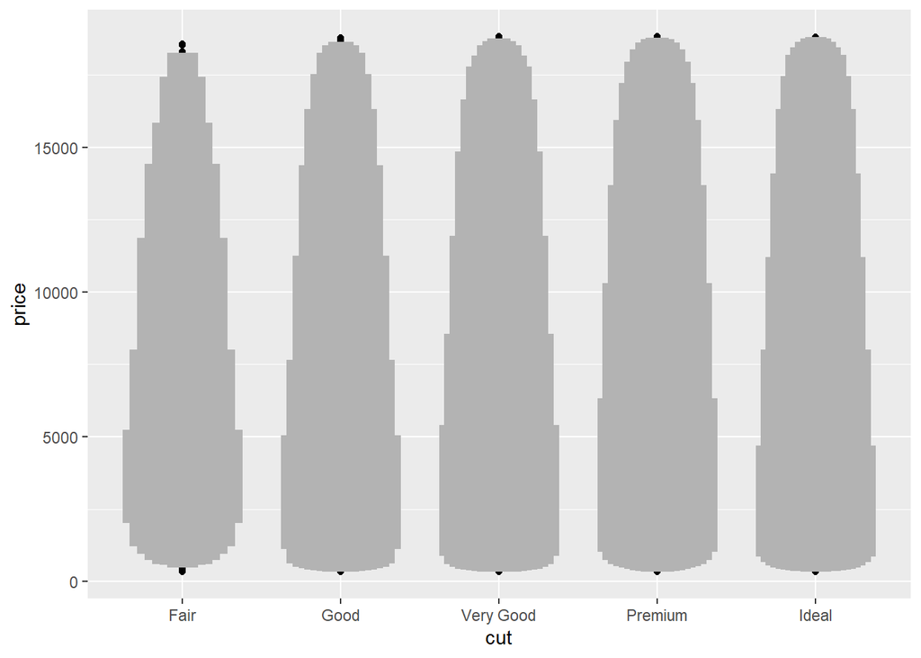

```r
ggplot(diamonds) + geom_lv(aes(x=cut,y=price))
```

Esse gráfico apresenta a quantidade de valores em certa area pela espessura da barra, os critérios de outliers para esse gráfico tambem são alterados, essas mudanças nos permitem interpretar melhor os valores da cauda dos boxplots.

5. Compare geom_violin com geom_histogram com varias faces.

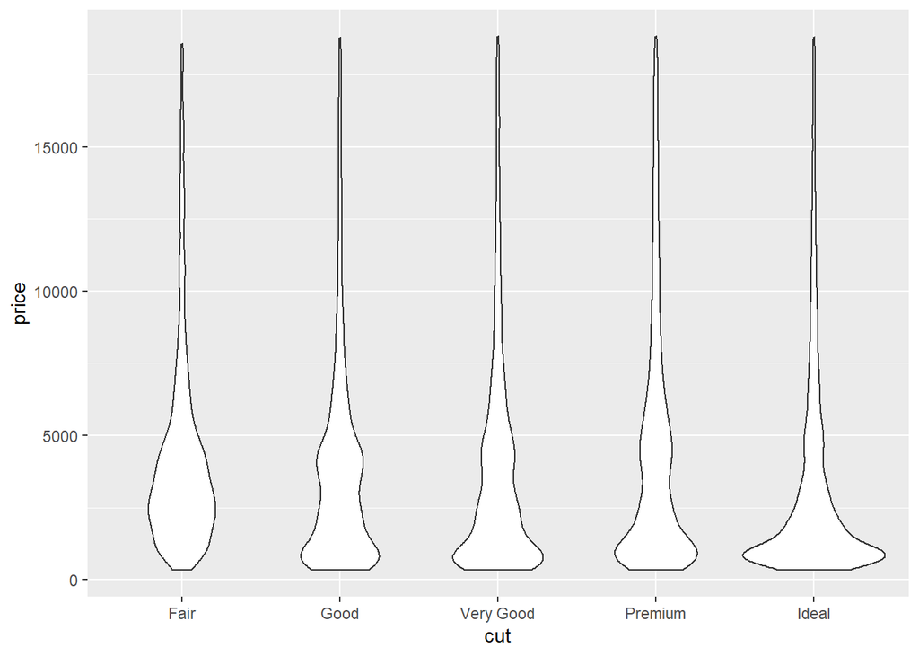

```r
ggplot(diamonds) + geom_violin(aes(x=cut,y=price))
```

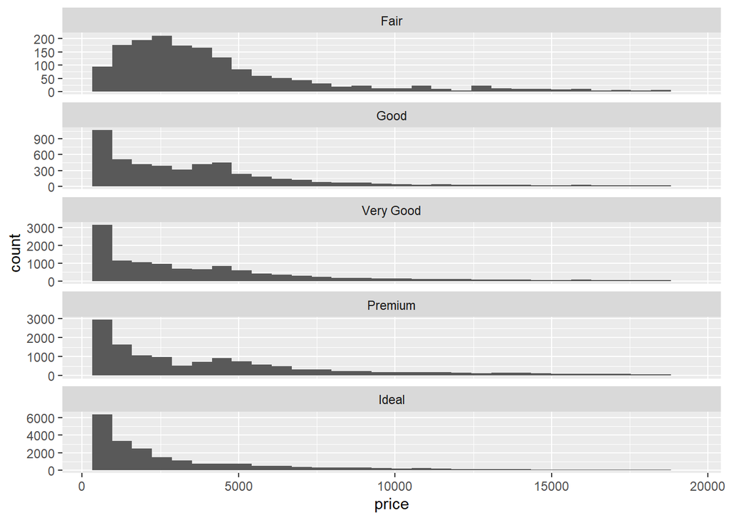

```r
ggplot(diamonds) + geom_histogram(aes(x=price)) + facet_wrap(~cut,ncol=1,scales='free_y')
```

Ambos estão fazendo a mesma função, o violino permite fazer uma comparação lado a lado mais interessante porem é menos preciso em relação a quantidade de valores presente nas áreas.

6. Quando temos datasets pequenos, usar geom_jitter é útil para analisar variáveis categóricas vs contínuas, o pacote ggbeeswarm tem funções parecidas, liste essas e de exemplos.

geom_beeswarm: Quando estamos plottando variáveis categóricas vs contínuas em pontos, essa função separa cada ponto em um valor espécifico da variável e permite que saibamos exatamente quantos pontos tem nesse local. Para conjuntos muito grandes pode atrapalhar. Melhor visualização que oo jitter que deixa tudo confuso em variáveis categóricas.

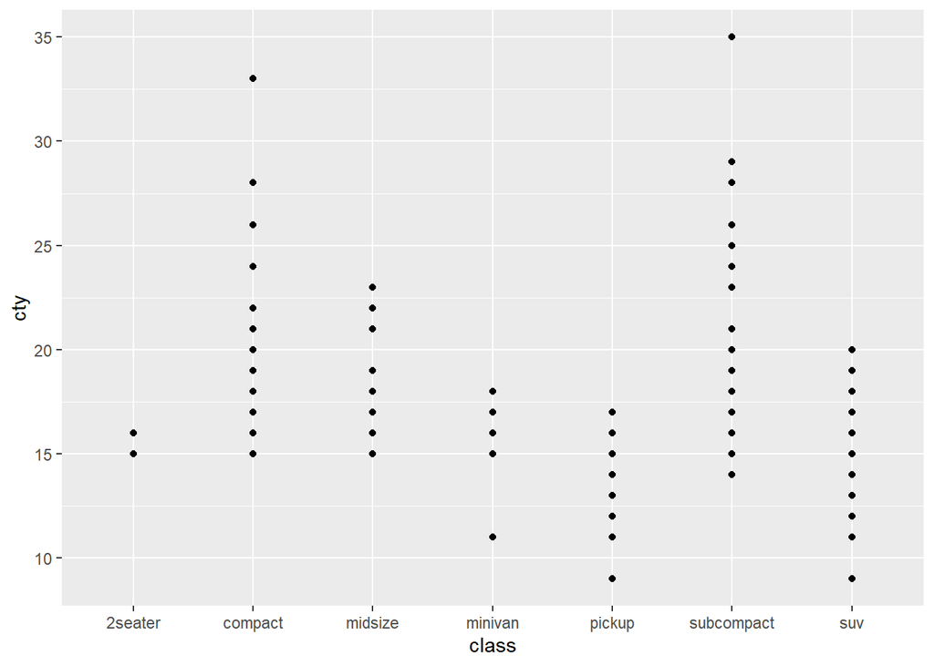

```r
mp <- ggplot(mpg,aes(x=class,y=cty))

mp+ geom_point()
```

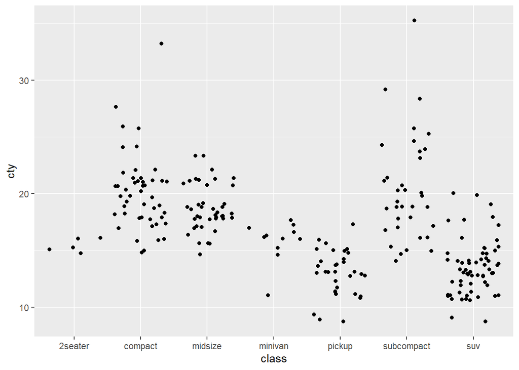

```r
mp+ geom_jitter()
```

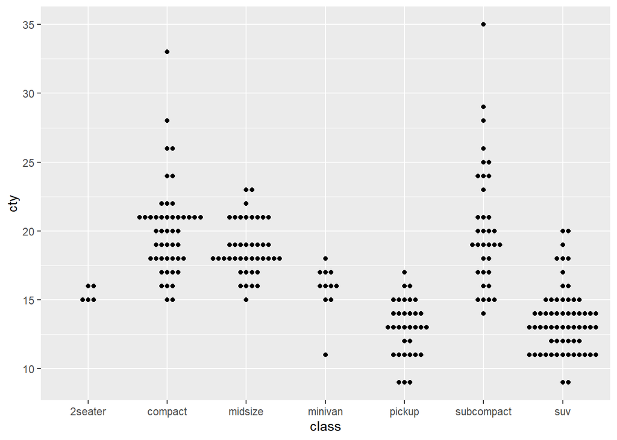

```r
mp+geom_beeswarm()
```

geom_quasirandom: Novamente separa os pontos porém de forma aletória e com ruidos apenas no eixo da variável categorica, permite visualizar os pontos exatamente. Facilita a visualização para poucos dados.

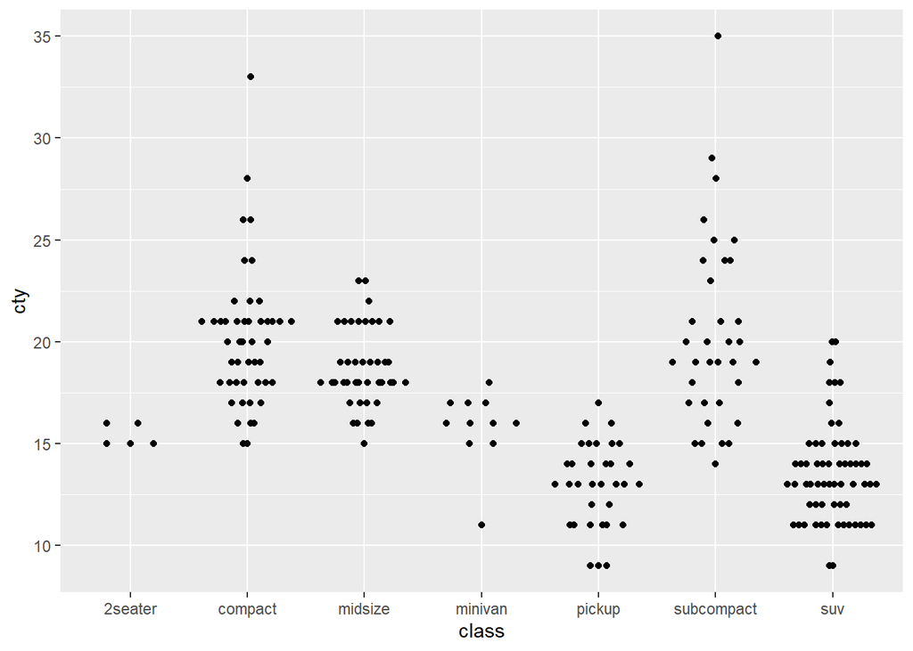

```r
mp+geom_quasirandom()
```

### 7.5.2 Two Categorical Variables

Para visualizar a covariação entre duas variáveis categóricas, voce precisa contar o número de observações de cada combinação. Uma maneira de fazer isso seria contar com o geom_count().

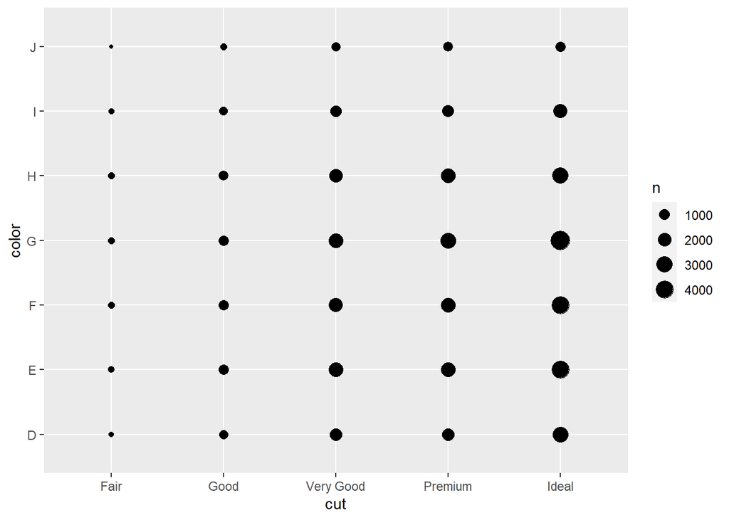

```r
ggplot(diamonds,aes(cut,color)) + geom_count()
```

O tamanho de cada círculo indica a quantidade de observações. Outra maneira é com o uso do dplyr.

```r
(conta <- mutate(diamonds,color=fct_rev(color)) %>% count(color,cut))
```

```
## # A tibble: 35 x 3
##    color cut           n
##    <ord> <ord>     <int>
##  1 J     Fair        119
##  2 J     Good        307
##  3 J     Very Good   678
##  4 J     Premium     808
##  5 J     Ideal       896
##  6 I     Fair        175
##  7 I     Good        522
##  8 I     Very Good  1204
##  9 I     Premium    1428
## 10 I     Ideal      2093
## # ... with 25 more rows
```

e depois visualizar com geom_tile() e aes fill.

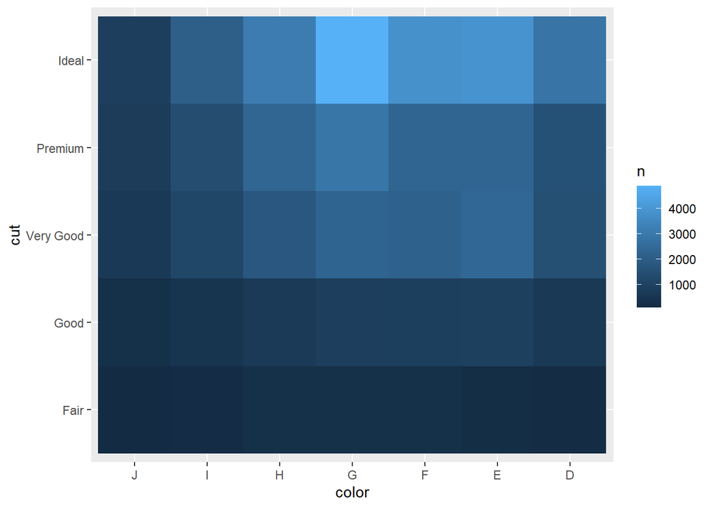

```r
ggplot(conta) + geom_tile(aes(x=color,y=cut,fill=n))
```

Se as variáveis não são ordenadas podemos usar o pacote seriation para simultaneamente reordenar as colunas e linhas para obter uma melhor visualização.

### Exercícios 7.5.2.1

1. Como poderia alterar o dataset count para melhorar a distribuição de cortes entre as cores?

Poderiamos cria uma variável proporção para apresentar a qualidade em relação ao tamanho do grupo.

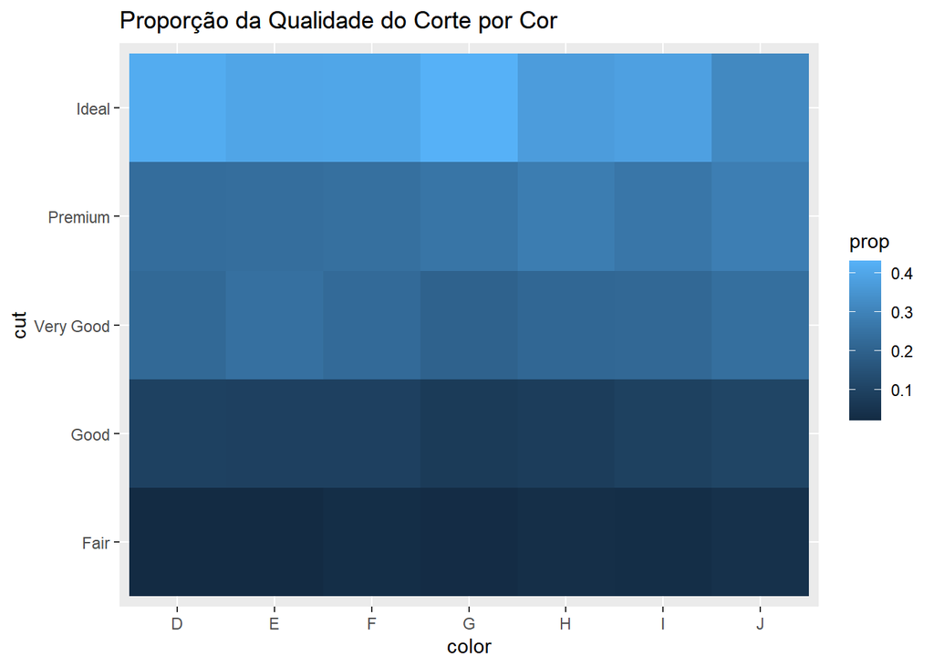

```r
diamonds %>% count(color,cut) %>% group_by(color) %>% mutate(prop = n/sum(n)) %>% ggplot(aes(x=color,y=cut)) + geom_tile(aes(fill=prop)) + labs(title = 'Proporção da Qualidade do Corte por Cor')
```

2. Use geom_tile e o dplyr para analisar como o delay medio dos voos varia por destino e mes.

```r
(atr <- flights %>% group_by(dest,month) %>% summarise(quant = n(),media = mean(dep_delay,na.rm = T)))
```

```
## # A tibble: 1,113 x 4
## # Groups:   dest [105]
##    dest  month quant media
##    <chr> <int> <int> <dbl>
##  1 ABQ       4     9  2.67
##  2 ABQ       5    31 11.6
##  3 ABQ       6    30 15.5
##  4 ABQ       7    31 24.3
##  5 ABQ       8    31 15.9
##  6 ABQ       9    30 19.2
##  7 ABQ      10    31  4.32
##  8 ABQ      11    30 -2.2
##  9 ABQ      12    31 24.3
## 10 ACK       5    21  9.05
## # ... with 1,103 more rows
```

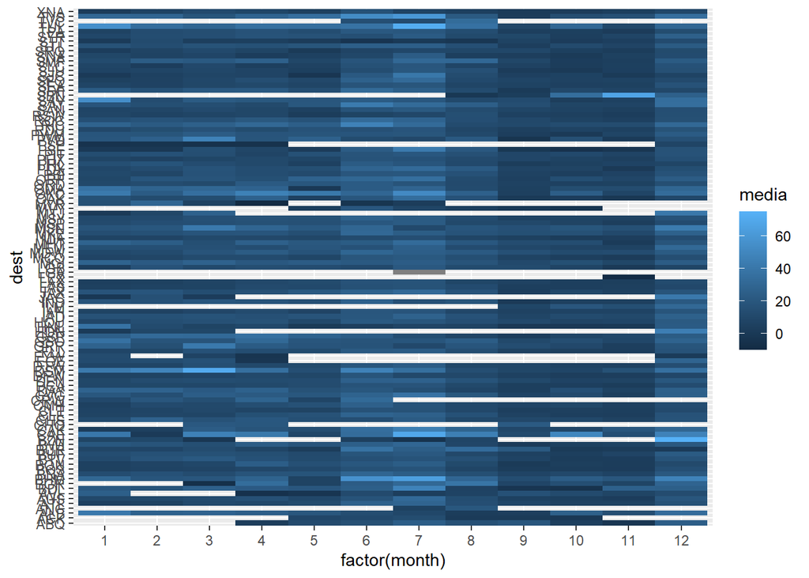

```r
ggplot(atr) + geom_tile(aes(x=factor(month),y=dest,fill=media))
```

O gráfico ficar extreamente poluído e difícil de interpretar. Um dos problemas é a grande quantidade de destinos, podemos escolher apenas destinos que acontecem muitos voos. Segundo poderiamos remover locais que não existem meses que não ocorrem voos.

```r
(atr2 <- atr %>% filter(quant>100) %>% group_by(dest) %>% filter(n() == 12)) #Mantendo apenas os destinos que tiveram mais de 100 voos todo mês
```

```
## # A tibble: 564 x 4
## # Groups:   dest [47]
##    dest  month quant media
##    <chr> <int> <int> <dbl>
##  1 ATL       1  1396  4.47
##  2 ATL       2  1267  5.96
##  3 ATL       3  1448 11.2
##  4 ATL       4  1490  9.52
##  5 ATL       5  1499 12.0
##  6 ATL       6  1438 25.8
##  7 ATL       7  1511 28.6
##  8 ATL       8  1507 14.5
##  9 ATL       9  1364  8.58
## 10 ATL      10  1448  5.58
## # ... with 554 more rows
```

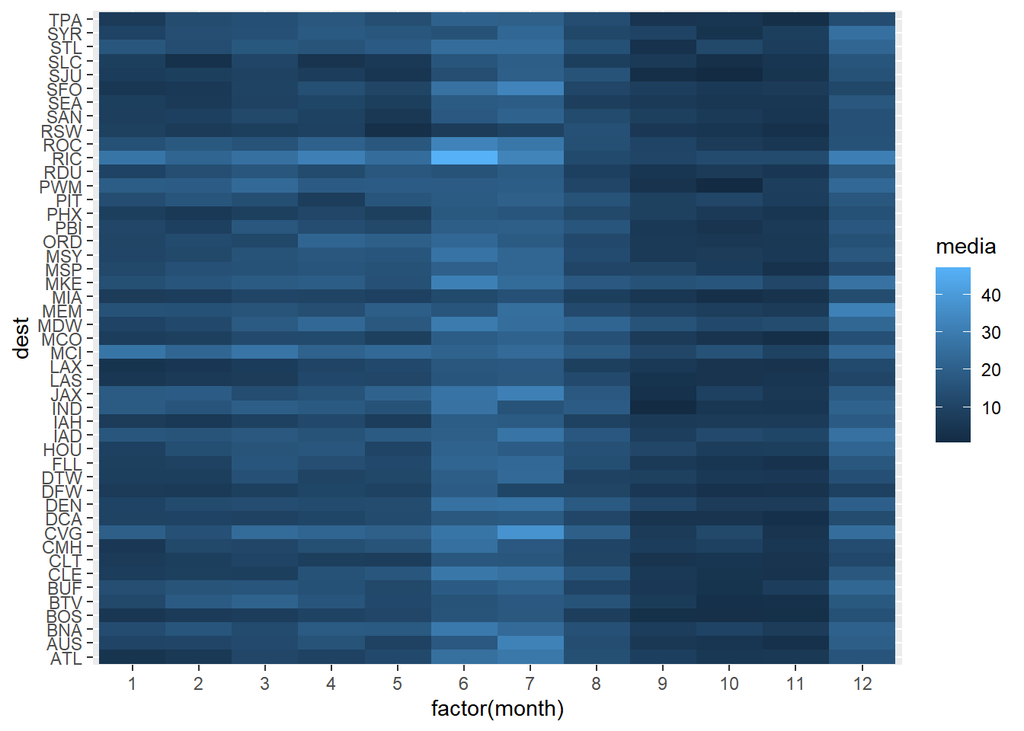

```r
atr2 %>% ggplot() + geom_tile(aes(x=factor(month),y=dest,fill=media))
```

A visualização ficou muito melhor e apresentou apenas destinos que tem muitos voos. Caso quisesemos os pequenos poderiamos fazer outro filtro e gráfico.

3. X = cut é melhor pois facilita sua leitura é facilitada eixo y.